# Diagnostics and benchmarking

This vignette shows the diagnostic and benchmarking workflow for `crr()` fits: the structured diagnostics report, the plotting methods, and the one-call benchmark against the unconstrained baseline. It mirrors, at a CRAN-friendly scale, the simulation comparisons in *Statistical Modeling of Combinatorial Response Data*.

## Setup: simulate and fit

```r
library(combreg)

A <- rbind(
  c(1, 1, 0),
  c(0, 1, 1)
)
con <- crr_constraints(A, b = c(1, 1))
sim <- simulate_crr(n = 300, p = 2, constraints = con, seed = 42)

fit <- crr(sim$Y, sim$X, con,
           n_iter = 4000, warmup = 2000, chains = 2, seed = 42)
fit
```

```
#> <crr_fit> method=mhwg kernel=exponential: n=300, p=2, d=3, chains=2, iterations=4000 (warmup 2000, thin 1)
#> Mean MH acceptance rate: 0.649
#> Total sampling time: 20.1s
```

## The diagnostics report

`crr_diagnostics()` assembles everything needed to judge a run in one object: per-coefficient posterior summaries, effective sample sizes (total and per second of sampling), split-Rhat, MH acceptance, in-sample regression fit, and posterior predictive goodness-of-fit checks. In simulation the true coefficients are known, so passing `beta` additionally reports estimation error (RMSE) and posterior-interval coverage. Potential problems (Rhat above 1.05, ESS below 100, very low acceptance, extreme predictive p-values) are collected as warnings.

```r
report <- crr_diagnostics(fit, beta = sim$beta)
report
```

```
#> Model ------------------------------------------------------------------
#>   method mhwg (exponential dual kernel): n = 300, p = 2, d = 3
#> Sampling ---------------------------------------------------------------
#>   2 chain(s), 4000 iterations (warmup 2000, thin 1); 4000 retained draws
#>   total time 20.1s, mean MH acceptance 0.649
#> Coefficients (posterior summary + MCMC diagnostics) --------------------
#>  parameter   mean     sd   q2.5  q97.5   ess ess_per_sec rhat
#>  beta[1,1] -0.303 0.0943 -0.484 -0.120 323.0       16.10 1.01
#>  beta[2,1]  0.464 0.0855  0.299  0.639 349.0       17.40 1.00
#>  beta[1,2]  0.909 0.1350  0.642  1.180 192.0        9.57 1.04
#>  beta[2,2]  0.842 0.1240  0.608  1.090 124.0        6.17 1.02
#>  beta[1,3] -0.606 0.1190 -0.834 -0.369 185.0        9.23 1.01
#>  beta[2,3]  1.650 0.1800  1.340  2.050  66.7        3.32 1.05
#>   worst split-Rhat 1.05; min ESS 66.7; min ESS/sec 3.32
#> Regression fit (training data) -----------------------------------------
#>   exact-match rate: 0.543  (fraction of rows with y_i == y_hat_i)
#>   per-coordinate accuracy: 0.690 0.817 0.823
#>   note: accuracy is bounded by the intrinsic utility noise; judge fit by the
#>   posterior predictive checks below, not by the raw rates.
#> Posterior predictive checks (50 replicates) ----------------------------
#>         statistic observed pred_mean pred_q5 pred_q95 p_value
#>       exact_match    0.543     0.545   0.500    0.601    0.96
#>       accuracy[1]    0.690     0.693   0.640    0.733    1.00
#>       accuracy[2]    0.817     0.802   0.768    0.839    0.64
#>       accuracy[3]    0.823     0.814   0.776    0.850    0.88
#>  marginal_freq[1]    0.403     0.425   0.386    0.476    0.56
#>  marginal_freq[2]    0.247     0.258   0.227    0.293    0.64
#>  marginal_freq[3]    0.430     0.411   0.358    0.450    0.60
#>   all observed statistics are typical of the fitted model
#> Estimation vs known truth ----------------------------------------------
#>   RMSE(beta): 0.0589
#>   95% interval coverage: 1
#> Warnings ---------------------------------------------------------------
#>   - split-Rhat > 1.05 for 1 parameter(s): beta[2,3]
#>   - ESS < 100 for 1 parameter(s): beta[2,3]
```

The underlying per-parameter table is available as `report$table`, and the predictive-check object as `report$ppc`.

### Reading the goodness-of-fit checks

The raw exact-match and accuracy rates are *not* by themselves evidence for or against the model: the response is the maximizer of a noisy utility, so even the true $\beta$ cannot predict $y_i$ perfectly — point-prediction accuracy is bounded by the intrinsic noise. The posterior predictive checks calibrate this. Each replicate re-simulates responses from the fitted model and recomputes the fit statistics; the model is adequate when the observed statistics are typical of that distribution (two-sided p-values away from 0). Here the observed exact-match rate sits in the middle of its predictive distribution — the seemingly modest rate is exactly what a *correct* model predicts for this noise level, and the RMSE and coverage against the known truth confirm accurate estimation. `crr_ppc()` runs the checks standalone with more replicates if needed.

## Plotting methods

All plots operate on the post-warmup, thinned draws.

Trace and autocorrelation:

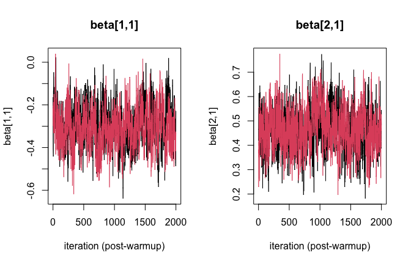

```r
plot(fit, type = "trace", pars = c("beta[1,1]", "beta[2,1]"))
```

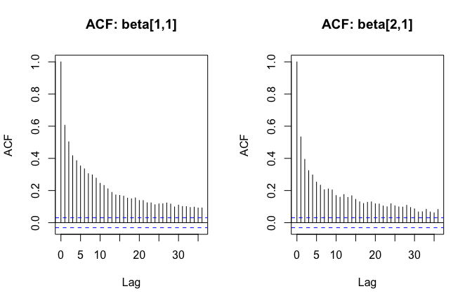

```r
plot(fit, type = "acf", pars = c("beta[1,1]", "beta[2,1]"))
```

Marginal posteriors of all coefficients as violins (median dot, central 95% interval bar):

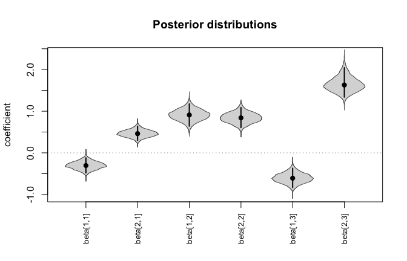

```r
plot(fit, type = "violin")
```

Effective sample sizes and sampling efficiency (ESS per second of sampling time, the efficiency measure used for method comparison in the paper):

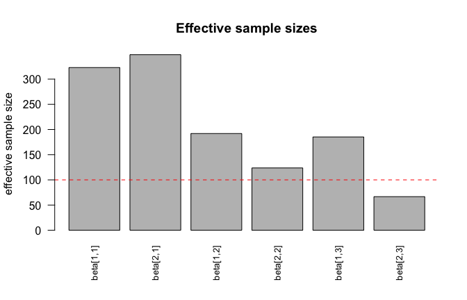

```r
plot(fit, type = "ess")
```

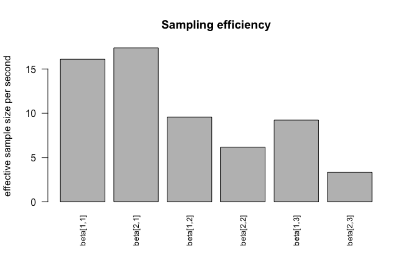

```r
plot(fit, type = "ess_time")
```

Residual heat map of the posterior point-estimate fit (`Y - fitted(fit)`, entries in $\{-1, 0, 1\}$):

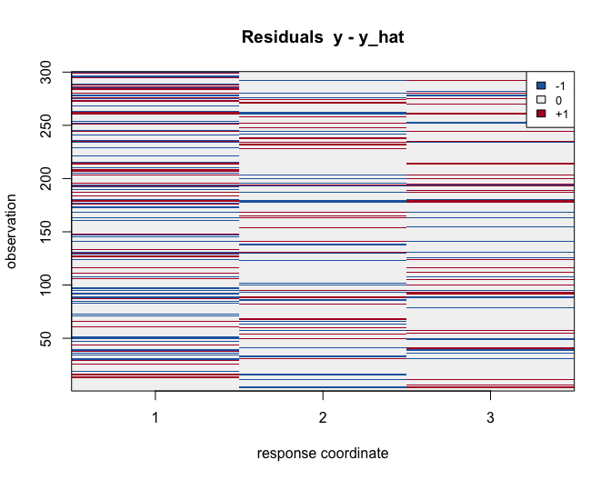

```r
plot(fit, type = "residual")
```

When the truth is known, the coefficient estimation error $\hat\beta - \beta$ as a heat map:

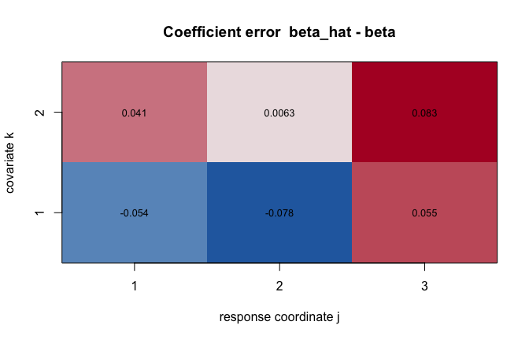

```r
plot(fit, type = "beta_diff", beta = sim$beta)
```

For anything beyond these built-ins, convert the draws with `coda::as.mcmc(fit)` or `posterior::as_draws(fit)` and use those ecosystems directly.

## Benchmarking against the unconstrained baseline

`crr_benchmark()` fits several methods to the same data with identical settings and reports timing, efficiency, in-sample fit, and — when the true coefficients are known, as in simulation — RMSE and posterior-interval coverage:

```r
bm <- crr_benchmark(sim$Y, sim$X, con, beta = sim$beta,
                    n_iter = 2000, warmup = 1000, seed = 42)
bm
```

```
#> <crr_benchmark>: 2 method(s), 95% intervals
#>         method time_sec accept_rate min_ess median_ess min_ess_per_sec
#>           mhwg    5.010       0.653      33       56.6             6.6
#>  unconstrained    0.574       1.000     111      283.0           194.0
#>  exact_match   rmse coverage
#>        0.543 0.0602    1.000
#>        0.443 0.4000    0.333
```

Two effects visible here reproduce the paper’s findings: the constrained sampler estimates $\beta$ with smaller error and better-calibrated intervals, because the unconstrained probit baseline conditions on each coordinate independently and is biased when responses are in fact constrained maximizers.

The fitted models are kept in `bm$fits`, so any of the diagnostics above can be applied to each method afterwards, e.g. `plot(bm$fits$unconstrained, type = "violin")`.